# SEAWINDS

Simon Lacombe

03/03/2021

# 1.Background

Flying over such long distances involves important energy expenditures (Ward, 2004). Thus, birds display many physiological and behavioral adaptations to reduce the energy costs associated with flying (Videler, 2006). One way to reduce theses costs is to take advantage of the wind conditions. For instance, a bird flying tailwind will spend less energy and go faster than a bird flying with no wind or with headwind (Elliott et al., 2014; Krietsch et al., 2020; Safi et al., 2013). Furthermore, although birds seem to be able to compensate for the drift associated with crosswind by shifting their direction, this compensation is costly and reducing the amount of crosswind encountered during the flight would reduce the time spent flying and the energy expenditure (Newton, 2010; Tarroux et al., 2016).

Many arctic bird species have thus been shown to adjust their flights according to the prevailing winds. For example, during their migration between the Arctic and Antarctica, Arctic terns *Sterna paradisaea* adjust their route to benefit from tailwind support, especially during the northbound migration before breeding (Hromádková et al., 2020). Pectoral sandpiper *Calidris melanotos* also adjust their movement to the prevailing winds. During the breeding season, male pectoral sandpipers sample several colonies to maximize their breeding success. Because mating opportunities in the colonies are unpredictable, the site they choose to visit is greatly influenced by the wind conditions at departure (Krietsch et al., 2020). Another interesting example is the one of Antarctic petrels, *Thalassoica antarctica*. These birds fly over long distances between their colony and their foraging areas with very strong winds. They have been shown to be able to adjust their flight altitude to minimize the effect of wind and to adjust their heading to compensate for the drift (Tarroux et al., 2016).

The black-legged kittiwake, *Rissa tridactyla*, is a pelagic seabird breeding at high latitudes along the Northern coasts of the Atlantic and Pacific (Daunt et al., 2002; Hatch et al., 2020). In winter, they migrate to the open ocean, with their non-breeding range covering a great part of both the Atlantic and the Pacific Ocean (Hatch et al., 2020). Their diet is mainly composed of fish, they may also feed on zooplankton (Mehlum and Gabrielsen, 1993). During the breeding period, they act as central place foragers, splitting their time between foraging flights (traveling flight and active foraging flights) and attending at the nest (Daunt et al., 2002). Daunt et al. (2002) showed that during this period, kittiwakes stay in close range to their breeding site (upper limit ca. 73km for kittiwakes on the Isle of May). This upper limit may be the result of both prey availability around the colony and the energetic costs associated with the traveling flight. Whether the wind conditions influence the range of the foraging flights around the colony, and whether it impacts the foraging efficiency during the breeding period is unknown.

Little is known concerning their movements outside the breeding season. Most kittiwakes from European colonies travel across the North-Atlantic to winter in the Labrador sea (Frederiksen et al., 2012; Swindells, n.d.). What determines the wintering? site of a given individual is unknown, with the principal wintering areas being shared between birds from many different colonies, whereas the birds from a given colony can winter in sites several thousand kilometers apart (Frederiksen et al., 2012; Orben et al., 2015; Swindells, n.d.). Kittiwakes generally winter in highly productive areas like oceanic gyres, shelf edges and upwelling zones (Frederiksen et al., 2012; Orben et al., 2015). These areas seem to provide more predictable resources (Weimerskirch, 2007) and kittiwake could thus specifically target them, travelling long distances without clear knowledge of the conditions at their arrival site. Furthermore, although black-legged kittiwakes are highly flexible regarding their wintering areas (important interannual variability), individual experiences seem to have an impact on the wintering destination of the birds, with individuals returning to previously visited areas more often than expected by chance (Orben et al., 2015). Together, prey predictability and individual experiences could explain the difference in wintering areas within and across colonies. Yet, for black-legged kittiwakes flying costs are high (Elliott et al., 2014) and reducing the energy expenditure to get to the foraging area could also impact their wintering distribution. **Wind may thus have an impact on their target destination by reducing the energy cost of the flight**. We could imagine that (1) wind at departure and during the flight partially determines the place of settlement; or that (2) birds time their departure according to the dominant wind to help them going to a determined place. In addition, beyond their migratory journey, foraging flight at their wintering location may represent important distances (no data found) and black-legged kittiwakes could adapt to wind conditions (either by avoiding strong wind, or by adjusting their heading to benefit from tailwind) in order to maximize the energy income while foraging. Finally, the effect of the weather conditions encountered in winter on their breeding success is unknown and it would be interesting to assess it.

# 2. Methods used to study wind and migrations

## Wind data:

*Several Datasets can be used*

- Direct measurements: **ASCAT** (scatterometry). Seems like ASCAT is the only direct measure available covering the period of interest. There could be an issue with the coverage of the daily data (due to the passage of the satellite above the Ocean).

To test this, I downloaded daily data of 2016-11. I counted the number of NA each day. As no data could be obtained above lands, many NA are only caused by the lands. I thus defined the size of the studied area as the number of pixels on the whole area, minus the minimal number of NA encountered. I quantified the relative difference between the daily number of NA and the size of the studied area. See the code and outputs below.

```r
netcdf_ = list.files(path="data/ASCAT", pattern = ".nc")

u = brick(paste0("data/ASCAT/", netcdf_), varname = "x_wind")
v = brick(paste0("data/ASCAT/", netcdf_), varname = "y_wind")

daily_na = c()
for (i in (1:nlayers(u)))
{
  daily_na = append(daily_na, length(which(is.na(u[[i]][]))))
}

study_area = length(u[[1]][])-min(daily_na) #size of the largest zone that can be studied in the sample
daily_na = (daily_na - min(daily_na))/study_area #proportion of the study area that is lost
print(daily_na)
```

```
##  [1] 0.011717228 0.000000000 0.007013638 0.013220150 0.002310047 0.009852491
##  [7] 0.005343724 0.011021431 0.005121069 0.012774840 0.022627331 0.016810465
## [13] 0.021347064 0.022070693 0.049485110 0.027748400 0.025605344 0.027191762
## [19] 0.017005288 0.032257167 0.022516003 0.034316727 0.044976343 0.044670192
## [25] 0.041246869 0.040300584 0.046173114 0.041525188 0.039521291 0.047119399
```

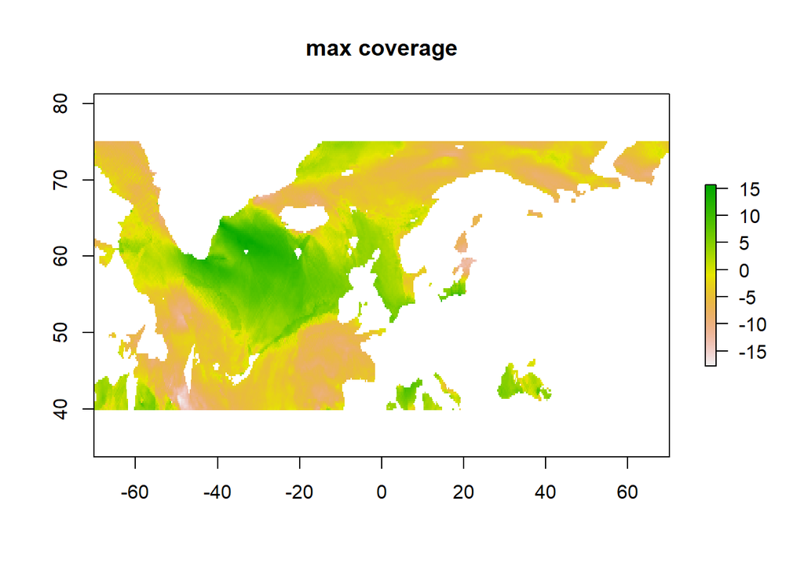

```r
plot(u[[which(daily_na==min(daily_na))]], main="max coverage")
```

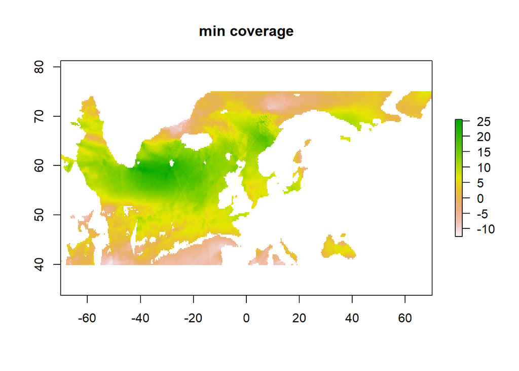

```r
plot(u[[which(daily_na==max(daily_na))]], main="min coverage")
```

The difference in coverage between days seems negligible (<5% of the studied area). Overall, the coverage of the data is sufficient to conduct daily analysis.

**ASCAT: 1 day; 0.25°; 2013-present; surface**

- Atmospheric reanalysis: **ERA-Interrim, ECMWF**. Reanalysis combine measurements with a forecast model. The fact that it is based on observations (*e.g.* several scatterometers used like QUICKSCAT before 2011) makes it a strong dataset. These data are used in (Hromádková et al., 2020; Krietsch et al., 2020) and (Dell’Ariccia et al., 2018) uses another reanalysis from the NOAA.

**ERA-Interrim: 6 hr; 0.75° (interpolated data are available); covering the whole period; several altitudes.**

## Light logger technology: CF (Lisovski et al., 2020)

## Vectors used

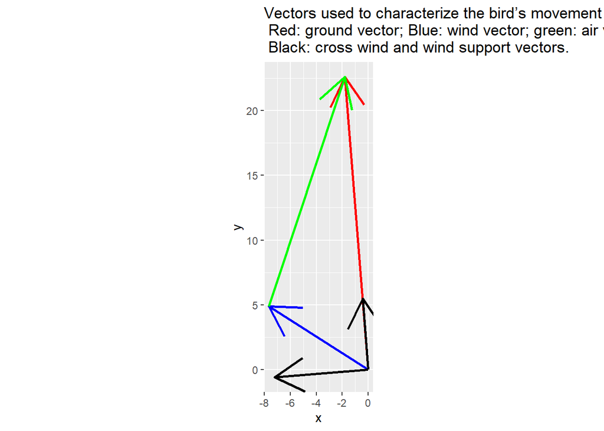

To analyse the birds’ track in relation with the wind, I defined several vector as follows:

- Ground vector $\vec{V_g}$: bird’s speed and direction relative to the ground. As birst don’t spend the whole day flying, ground speed $||\vec{V_g}||$ is defined as follows: $||\vec{V_g}|| = d/ \Delta t(1-cond)$ where $d$ is the distance travelled between two positions, $dt$ the time between these two positons, and $cond$ is the mean conductivity recorded between $t$ and $t+dt$. $cond$ is a proxy of the fraction of the time spent in watter, thus, $(1-cond)$ is a proxy of the time spent flying.
- Wind vector $\vec{V_w}$: daily or monthly wind vector derived from $u$ and $v$ wind speed obtained with the ASCAT datasets. The wind vector is decomposed into wind support $\vec{W_s}$, the projection of $\vec{V_w}$ on $\vec{V_g}$ and cross wind $\vec{V_c}$.
- Air vector $\vec{V_a}$: bird’s speed and direction relative to the air. $\vec{V_a} = \vec{V_g} - \vec{V_w}$

## Biases, spatial and temporal resolution, …

CF Safi & al, 2013

# 3. Problematic and predictions

Do black legged kittiwakes take advantage of winds when they migrate? Do they adapt their route and their flying behavior to take advantage of winds?

**Predictions**:

1. Flying with tailwind reduces the energy cost of the flight and increases the ground speed.
- $V_a$ decreases with $WS$ and $V_g$ is constant if the bird minimizes energy expenditure. If the bird maximises travel speed, $V_a$ is constant and $V_g$ increases with $WS$.
- Wind effect $V_a \propto V_g - V_a$ (I need to read papers about this one).
2. The birds follow the tracks that takes most advantage of tailwind support.
- Overall, $WS > 0$. This effect shall be stronger if we consider the individual tracks.
- Wind support is significantly higher on the actual track compared with wind support on randomly created tracks or on straight line.
- Ground direction is correlated with wind direction.
- On a least cost map (in terms of energy expenditure or travel time) between two locations, birds routes would use optimal pixels more than expected by chance.
3. Bird would adapt their flying vs resting behavior based on the wind encountered.
- $cond$ increases with $V_w$ if the birds don’t fly when the wind is too strong.
- $cond$ is lower for values of $u_{wind}$ and $v_{wind}$ matching the overall migration direction. A linear model could be informative ($cond = f(u_{wind}, v_{wind}, d)$ where $d$ is the distance to the colony).
4. If we have enough time, an aspect I’m very interested in is the interannual (and intercolonial) variability of wind support: for instance, no annual variability in WS as well as a variability in wind conditions and migratory tracks could be indicative of behavioral adjustment to wind conditions (be it a shift in the migratory route or the destination).

# 4. Analysis

To test these predictions, I have analyzed the birds’ tracks by calculating the vectors defined above for all positions of all individuals. The same analysis was conducted, with wind and ground vectors averaged by month and by pixels (1° x 1°).

**I removed from the study the points when birds traveled less than 10% of the day, because these points lead to huge groun speeds (the uncertainty due to the GLS becomes greater than the real movement)**

*effect of wind speed on the ground and ir vectors* (I didn’t know how to link it to one of my predictions)

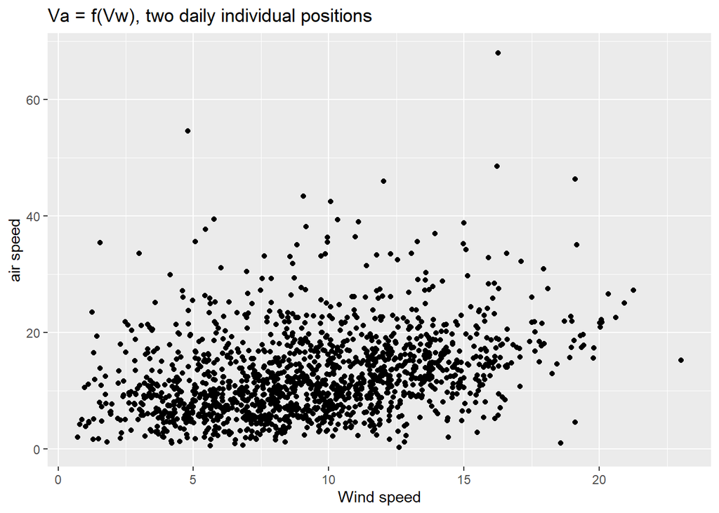

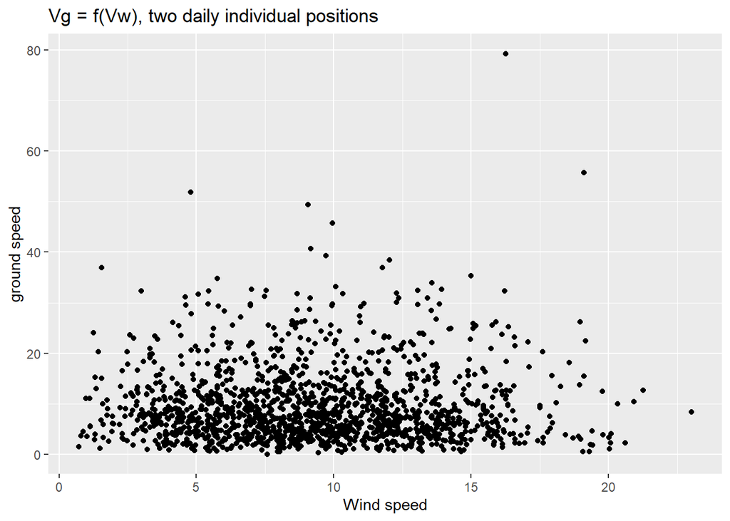

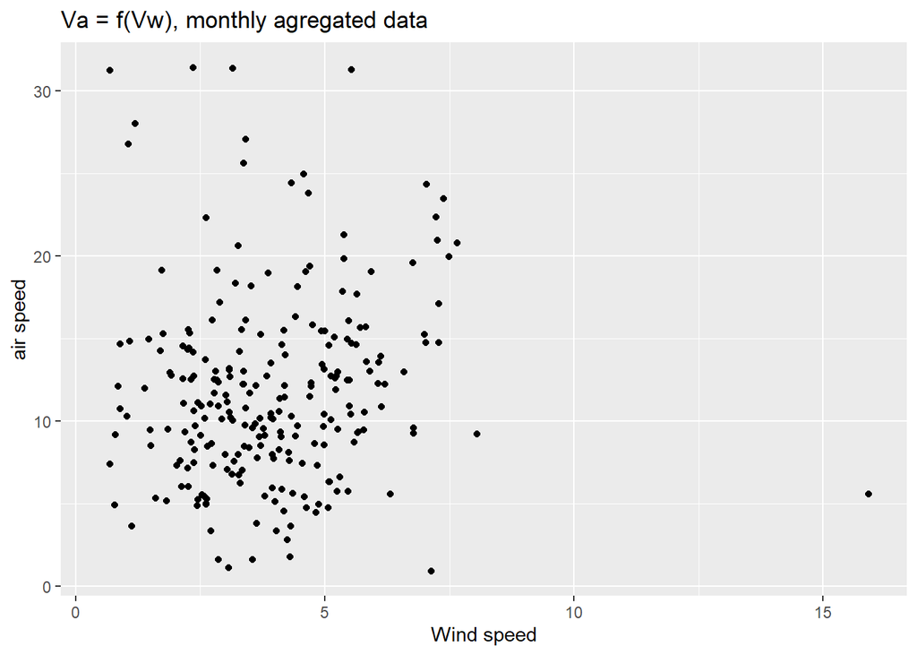

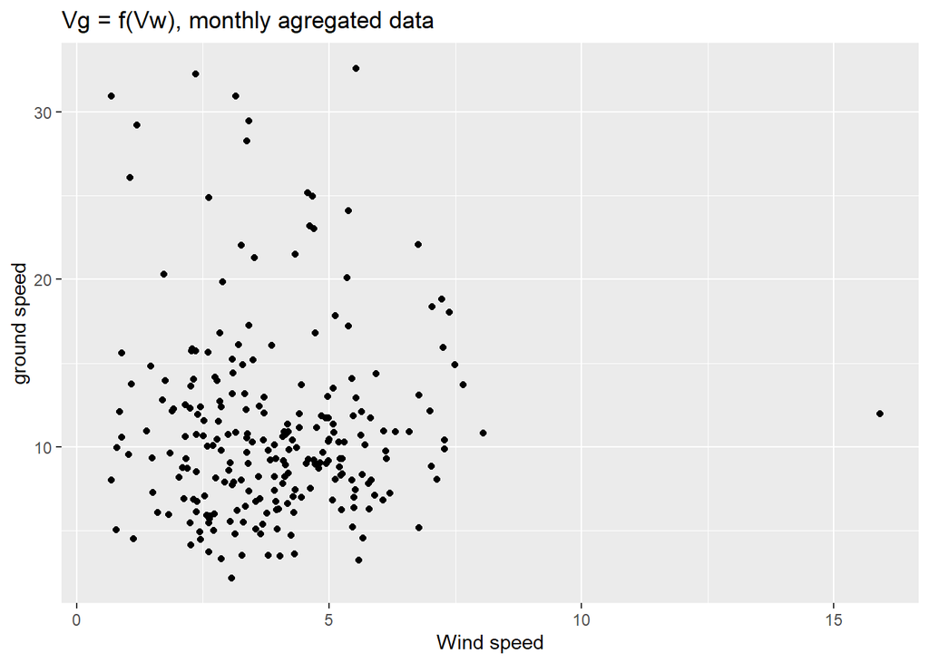

1. *Prediction 1*
- $V_a$ and $V_g$ as a function of $WS$

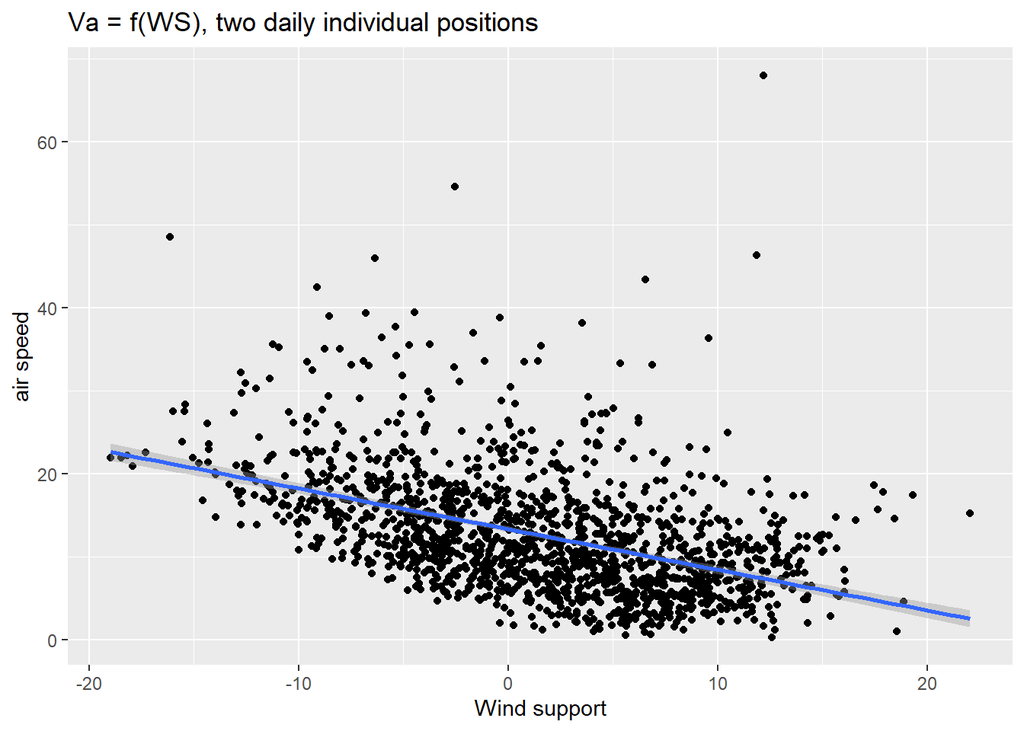

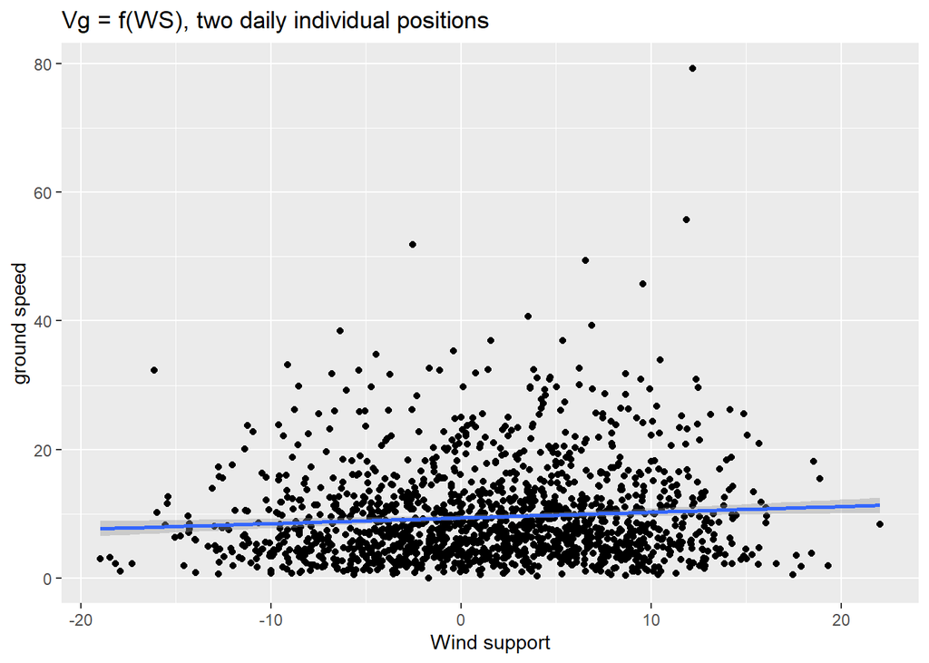

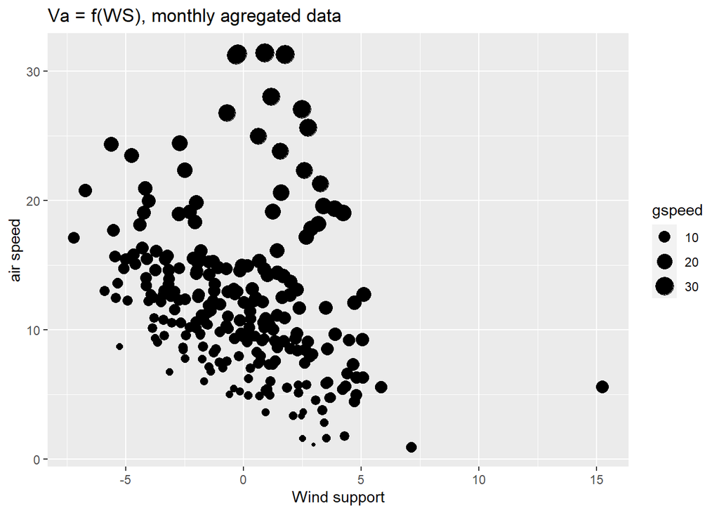

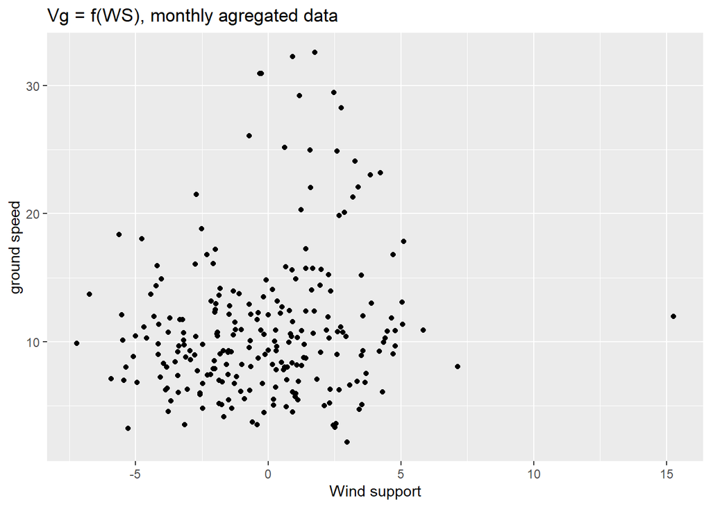

- Wind effect

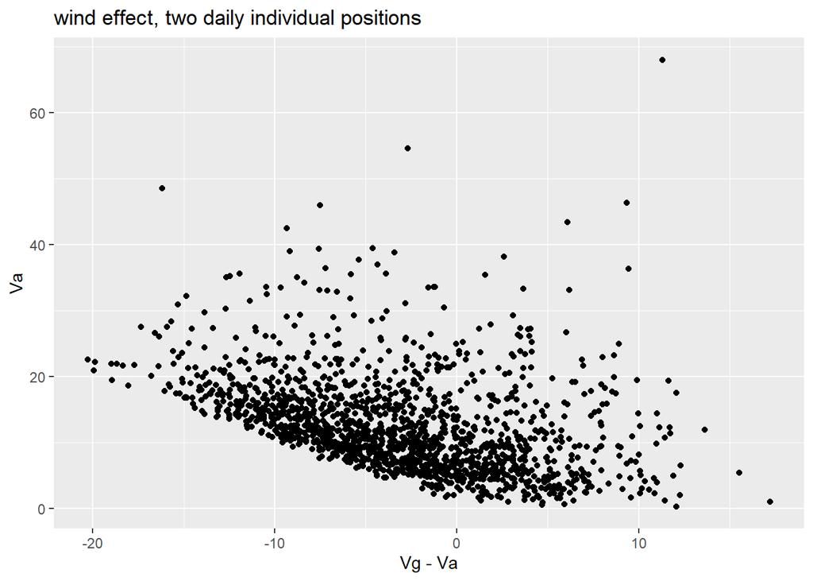

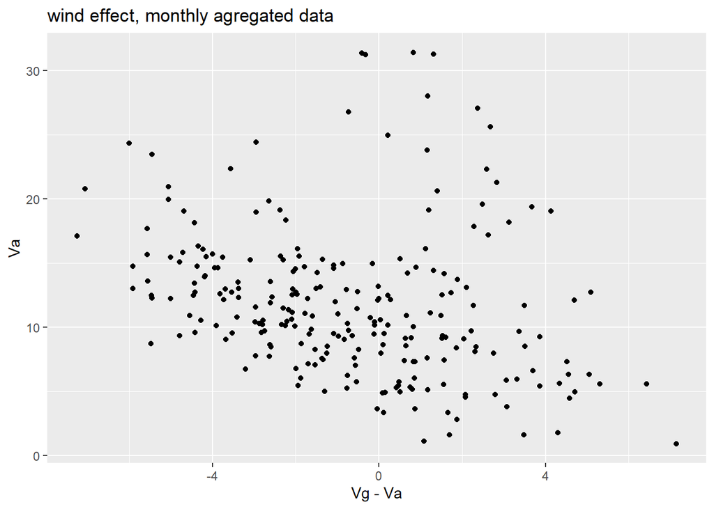

2. *Prediction 2*
- Overall value of wind support:

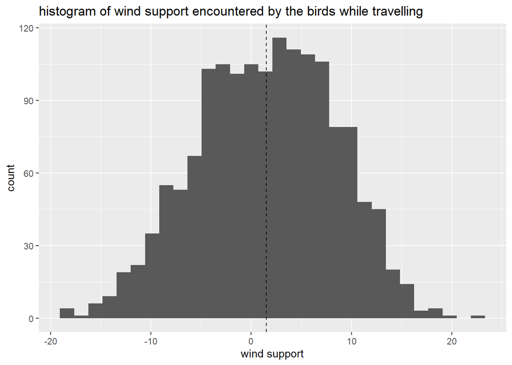

Using two values of wind support per day, based on the daily wind conditions we find that $WS > 0$ $(***)$. Using monthly agregated values, it appears that this information is lost, $WS$ is not significantly different from 0 (See histogram below).

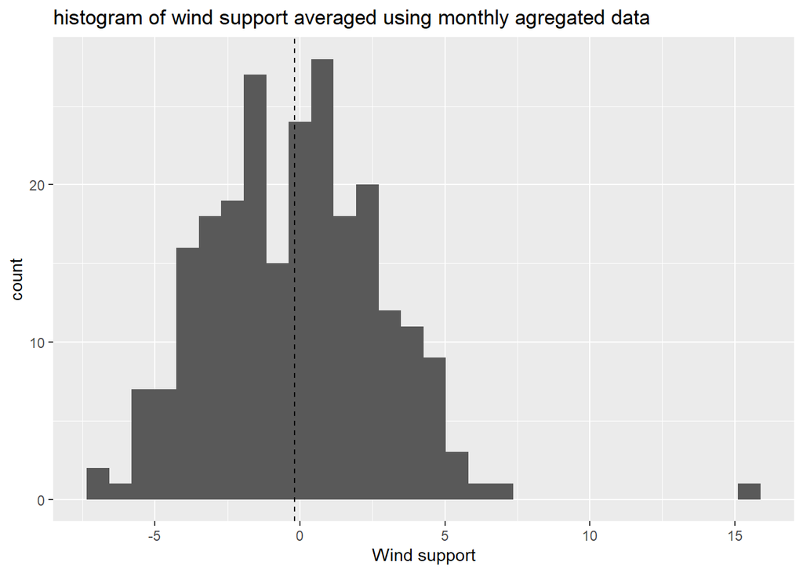

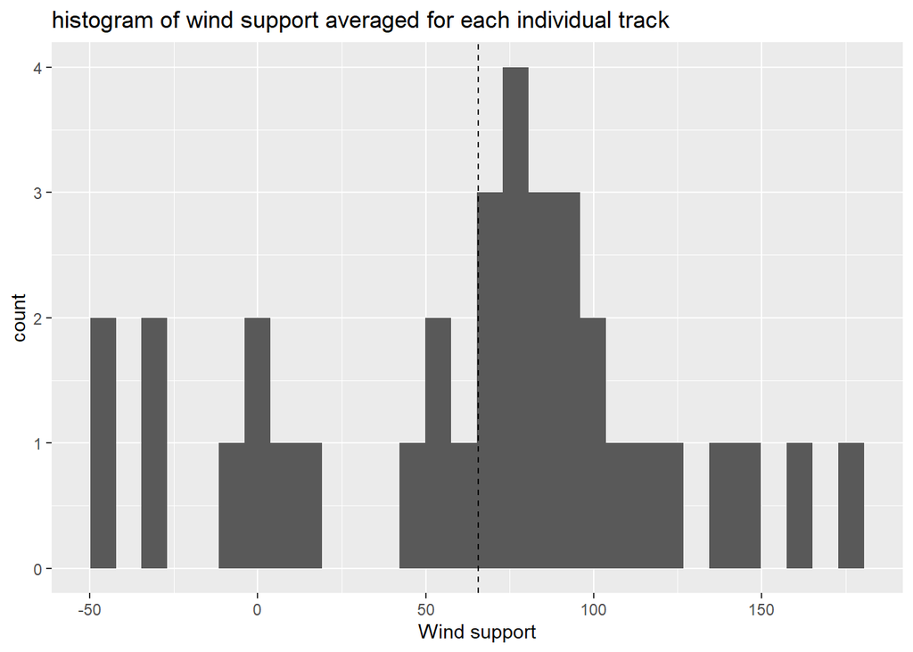

- correlation between wind direction and ground direction

I don’t know how to test this correlation. I tried with a circular correlation coefficient and found $r^2 \simeq -0.23$ with a p-value $< 0.001$. I don’t know how relevant this coefficient is. I also found that a coefficient called $\rho_v^2$ would be relevant (many references using this coefficients) but I haven’t yet found how to compute it with R.

I plotted on maps of the North Atlantic Ocean the mean wind direction and speed, and the mean ground direction and speed of the birds (see below).

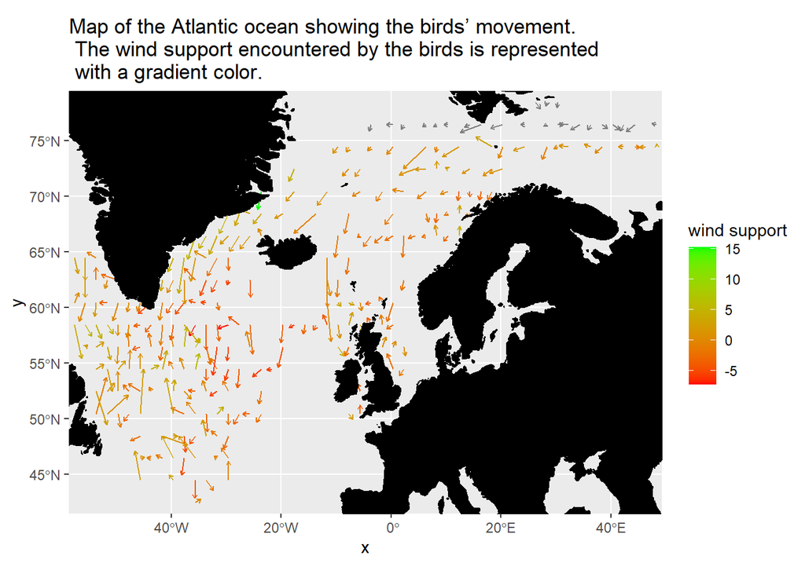

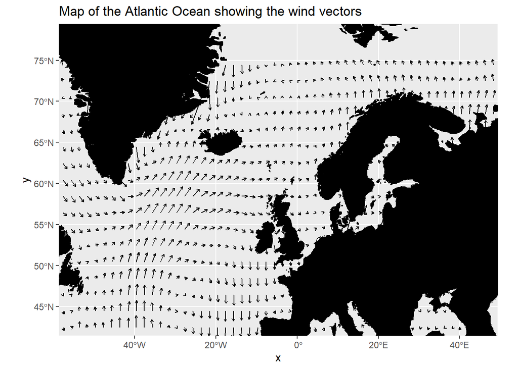

3. *Prediction 3*

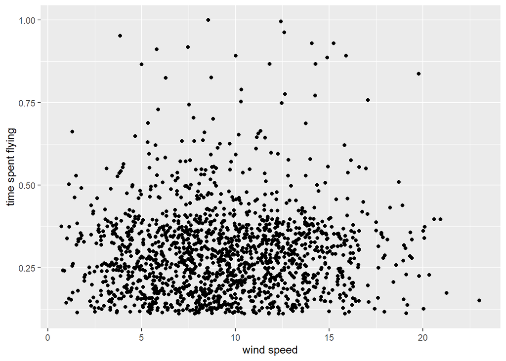

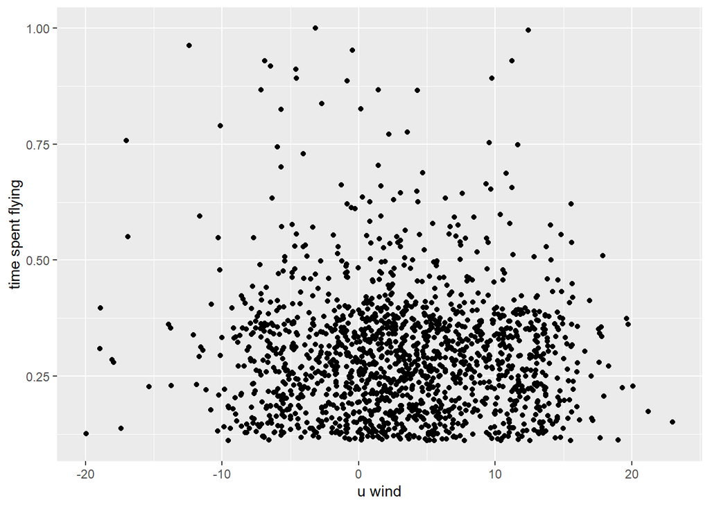

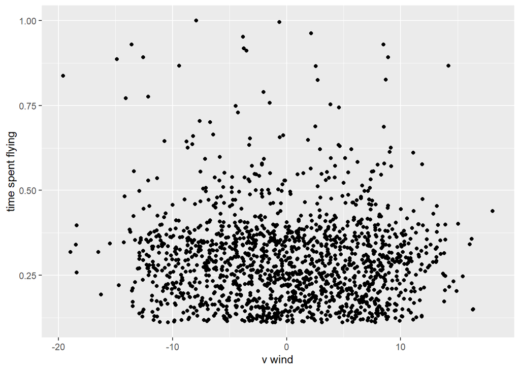